# Analyse des subventions accordées par la ville de Paris aux associations.

Trésor Djonga

## Préparation des données

Les données viennent du site https://opendata.paris.fr/. Le dataset au format csv contient les subventions annuelles de 2013 à 2020 accordées par les associations par la ville de Paris.

Les variables contenues dans le dataset sont:

1. Année budgétaire
2. Collectivité
3. Nom Bénéficiaire
4. Numéro Siret
5. Objet du dossier
6. Montant voté
7. Direction
8. Nature de la subvention

Le dernier graphique est une cartographie des EHPAD parisiens appartenant CASVP. Je n’ai pas trouvé le fichier des adresses des association me permettant de faire la jointure par numéro Siret.

Importation des librairies nécéssaires.

```r
rm(list=ls())
library(readr)
library(rjson)
library(dplyr)
```

```r
library(tidyr)
library(ggplot2)
library(leaflet)
```

Chargement du répértoire par défaut.

```r
setwd("C:\\Users\\Djonga\\Desktop\\DU BIG DATA\\M4\\J1-J2\\projet")
```

Importaion du fichier csv vers Rstudio.  
Puisque les noms des colonnes sont en français et contient des accents et espaces, nous allons les renommer directement.

```r
subventions <- read.csv("subventions.csv",
sep = ";", header = T, encoding = "UTF-8", skip = 1,
col.names = c("numDossier", "yearBudget", "community", "nameGranted", "numSiret", "object", "amount", "Direction", "typeGrant", "activityArea"))

str(subventions)
```

```
## 'data.frame':    61223 obs. of  10 variables:
##  $ numDossier  : Factor w/ 61200 levels "2011_00106","2011_03346",..: 32411 26679 28143 28145 26680 30783 25260 28041 31139 31671 ...
##  $ yearBudget  : int  2016 2016 2016 2016 2016 2016 2016 2016 2016 2016 ...
##  $ community   : Factor w/ 2 levels "Département de Paris",..: 2 2 2 2 2 2 2 2 2 2 ...
##  $ nameGranted : Factor w/ 9359 levels "","\"ACP  LA MANUFACTURE CHANSON\"(DOUBLON AVEC LE 181331 CHANGEMENT DE NATURE JURIDIQUE)",..: 5762 5770 5770 5770 5770 5800 23 5390 5390 5832 ...
##  $ numSiret    : Factor w/ 8591 levels "","0000000000",..: 6211 2816 2816 2816 2816 6617 6464 1546 1546 3737 ...
##  $ object      : Factor w/ 39483 levels "'Au delà des clichés'''Rencontres et transversalités au service de la citoyenneté.",..: 19959 17690 32847 36405 588 15594 30537 9288 9915 18092 ...
##  $ amount      : int  1500 0 1850 1000 0 4000 0 2000 1000 36000 ...
##  $ Direction   : Factor w/ 27 levels "CASVP","DAC",..: 7 7 5 7 7 2 2 5 7 3 ...
##  $ typeGrant   : Factor w/ 4 levels "Fonctionnement",..: 4 3 4 4 3 1 3 4 4 2 ...
##  $ activityArea: Factor w/ 773 levels "","Aides aux associations",..: 506 251 251 251 251 334 213 304 304 672 ...
```

```r
#Noms des colonnes
names(subventions)
```

```
##  [1] "numDossier"   "yearBudget"   "community"    "nameGranted"
##  [5] "numSiret"     "object"       "amount"       "Direction"
##  [9] "typeGrant"    "activityArea"
```

```r
#début du fichier
head(subventions)
```

```
##   numDossier yearBudget      community                    nameGranted
## 1 2016_08497       2016 Ville de Paris               LA FABRIQ DU 20°
## 2 2016_02539       2016 Ville de Paris LA FABRIQUE DES PETITS HASARDS
## 3 2016_04025       2016 Ville de Paris LA FABRIQUE DES PETITS HASARDS
## 4 2016_04027       2016 Ville de Paris LA FABRIQUE DES PETITS HASARDS
## 5 2016_02540       2016 Ville de Paris LA FABRIQUE DES PETITS HASARDS
## 6 2016_06776       2016 Ville de Paris              LA GIRAFE LYRIQUE
##         numSiret
## 1 79168765000014
## 2 48013001200044
## 3 48013001200044
## 4 48013001200044
## 5 48013001200044
## 6 79916293800010
##                                                                                               object
```

[output cut: 20 more lines]

## Analyse statistique et visualisation.

1.Nombre d’associations ayant obtenues une subvention et histogramme des montants accordés

```r
#Les associations soumettent les dossiers chaque année, elles sont donc sur plusieurs lignes.
subventions %>% select(numSiret) %>% distinct %>% count
```

```
## # A tibble: 1 x 1
##       n
##   <int>
## 1  8591
```

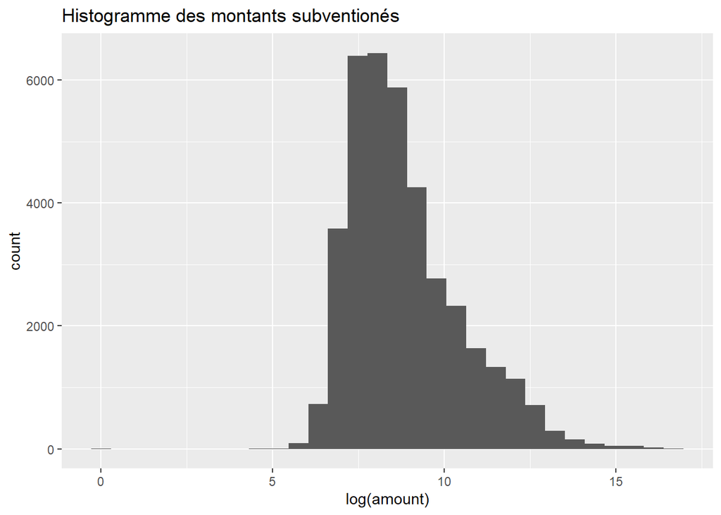

```r
#Histogramme. Les montants accordés aux associations sont en millions, on va les transformer en logarithme
ggplot(subventions) + geom_histogram(aes(log(amount)))+ ggtitle("Histogramme des montants subventionés")
```

2.Montant moyen accordé par an.

```r
df <- subventions %>% group_by(yearBudget) %>% summarise ("mean" = mean(amount))
df
```

```
## # A tibble: 8 x 2
##   yearBudget   mean
##        <int>  <dbl>
## 1       2013 28976.
## 2       2014 33757.
## 3       2015 32971.
## 4       2016 31226.
## 5       2017 31972.
## 6       2018 32318.
## 7       2019 30457.
## 8       2020 60640.
```

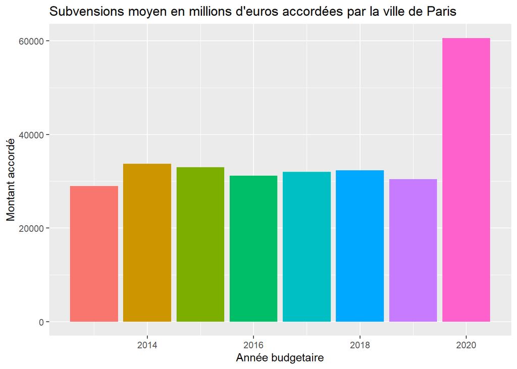

```r
ggplot(df) + geom_bar(aes(x = yearBudget, y = mean, fill=rownames(df)), stat = "identity") +
  guides(fill=FALSE)+
  ggtitle("Subvensions moyen en millions d'euros accordées par la ville de Paris") +
  xlab("Année budgetaire") +
  ylab("Montant accordé")
```

3.Proportion des dossiers étudiés par an.

```r
df <- subventions %>% group_by(yearBudget) %>% summarise ("Nbr" = n()) %>% mutate(Proportion=100*(Nbr/sum(Nbr)))
df
```

```
## # A tibble: 8 x 3
##   yearBudget   Nbr Proportion
##        <int> <int>      <dbl>
## 1       2013  8300      13.6
## 2       2014  7650      12.5
## 3       2015  8214      13.4
## 4       2016  8818      14.4
## 5       2017  8640      14.1
## 6       2018  8397      13.7
## 7       2019  9564      15.6
## 8       2020  1640       2.68
```

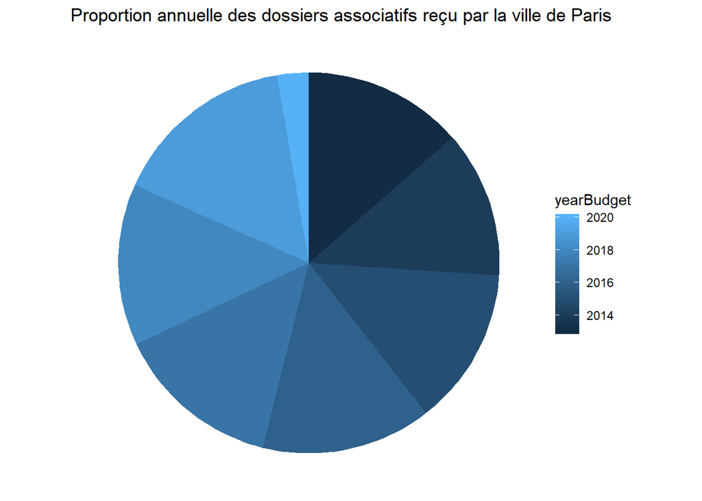

```r
#Graphique pour les proportions
ggplot(df, aes(x="", y=Proportion, fill=yearBudget))+
geom_bar(width = 1, stat = "identity") + coord_polar("y", start=0) +
theme_void() +
ggtitle("Proportion annuelle des dossiers associatifs reçu par la ville de Paris")
```

4.Nombre des dossiers étudiés par année, comparer accepté refusé.

```r
df <- subventions %>% mutate(flag_accord = ifelse(amount == 0, "Accordée", "Réfusée")) %>% group_by(yearBudget,flag_accord) %>% summarise (nb = n())
df
```

```
## # A tibble: 16 x 3
## # Groups:   yearBudget [8]
##    yearBudget flag_accord    nb
##         <int> <chr>       <int>
##  1       2013 Accordée     3378
##  2       2013 Réfusée      4922
##  3       2014 Accordée     2857
##  4       2014 Réfusée      4793
##  5       2015 Accordée     3512
##  6       2015 Réfusée      4702
##  7       2016 Accordée     3464
##  8       2016 Réfusée      5354
##  9       2017 Accordée     3182
## 10       2017 Réfusée      5458
## 11       2018 Accordée     2986
## 12       2018 Réfusée      5411
## 13       2019 Accordée     3664
## 14       2019 Réfusée      5900
## 15       2020 Accordée      247
## 16       2020 Réfusée      1393
```

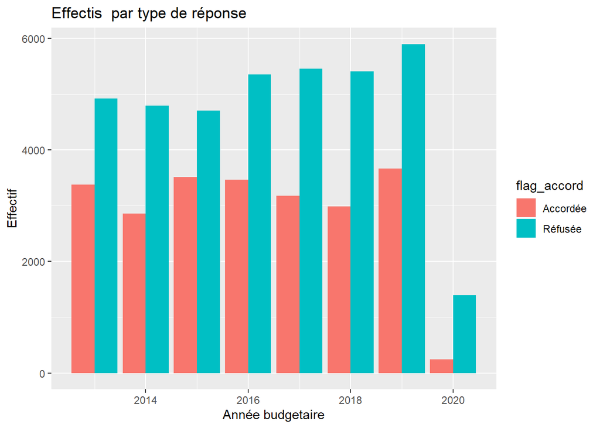

```r
ggplot(df, aes(x = yearBudget, y = nb, fill = flag_accord))  + geom_bar(stat = "identity",
    position = "dodge") +
    ggtitle("Effectis  par type de réponse") +
    xlab("Année budgetaire") +
    ylab("Effectif")
```

5. Association ayant plus grande subvention par annnée et leurs secteurs d’activités.

```r
df <- subventions %>% group_by(yearBudget)%>% select(yearBudget,numSiret,amount,activityArea)%>%arrange(desc(amount))%>%slice(1)
df
```

```
## # A tibble: 8 x 4
## # Groups:   yearBudget [8]
##   yearBudget numSiret       amount activityArea
##        <int> <fct>           <int> <fct>
## 1       2013 316696160000~  1.74e7 Culture & Arts;Education & formation;Id~
## 2       2014 316696160000~  1.72e7 Culture & Arts;Education & formation;Id~
## 3       2015 316696160000~  1.62e7 Culture & Arts;Education & formation;Id~
## 4       2016 323857219000~  1.03e7 Social
## 5       2017 323857219000~  1.03e7 Social
## 6       2018 323857219000~  1.16e7 Social
## 7       2019 323857219000~  1.24e7 Social
## 8       2020 316696160000~  1.01e7 Culture & Arts
```

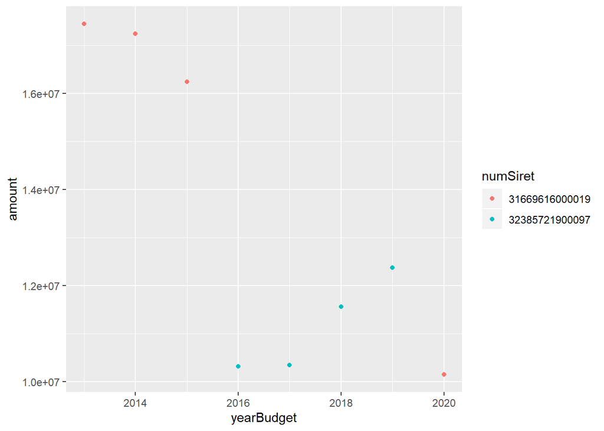

```r
ggplot(df) +
  geom_point(aes(x = yearBudget, y = amount, color = numSiret))
```

##Cartographie des EHPAD Parisiens.

On se propose cartographier les ehpads Parisien dependant de casvp puis affichier sur la carte les nombres des places libres et le contact.

Les données proviennent du sitehttps://www.data.gouv.fr/fr/datasets/casvp-liste-des-ehpad/.

```r
#Information sur les ehpad
ehpad <- read.csv("liste-des-ehpad.csv",
sep = ";", header = T, encoding = "UTF-8",
col.names = c("nom", "adresse", "ville", "postale", "coordonnees", "telephone", "amount", "image"))
str(ehpad)
```

```
## 'data.frame':    10 obs. of  8 variables:
##  $ nom        : Factor w/ 10 levels "ALICE PRIN","ALQUIER DEBROUSSE",..: 4 2 8 3 7 5 1 6 10 9
##  $ adresse    : Factor w/ 10 levels "1, allée Alquier Debrousse",..: 10 1 4 8 3 7 6 9 2 5
##  $ ville      : Factor w/ 1 level "Paris": 1 1 1 1 1 1 1 1 1 1
##  $ postale    : int  75015 75020 75005 75013 75015 75014 75014 75019 75018 75014
##  $ coordonnees: Factor w/ 10 levels "48.821531,2.347932",..: 6 8 5 1 7 3 2 9 10 4
##  $ telephone  : Factor w/ 10 levels "01 40 40 55 55",..: 2 4 6 8 9 5 10 1 3 7
##  $ amount     : Factor w/ 10 levels "https://opendata.paris.fr/api/v2/catalog/datasets/liste-des-ehpad/files/1ac46fddebf26ac5da3b93f09fadcb02",..: 8 2 4 5 10 3 7 6 9 1
##  $ image      : logi  NA NA NA NA NA NA ...
```

```r
#Noms des colonnes
names(ehpad)
```

```
## [1] "nom"         "adresse"     "ville"       "postale"     "coordonnees"
## [6] "telephone"   "amount"      "image"
```

```r
#début du fichier
head(ehpad)
```

```
##                  nom                    adresse ville postale
## 1      ANSELME PAYEN            9, place Violet Paris   75015
## 2  ALQUIER DEBROUSSE 1, allée Alquier Debrousse Paris   75020
## 3 JARDIN DES PLANTES     18, 22 rue de Poliveau Paris   75005
## 4     ANNIE GIRARDOT   6, 12 rue Annie Girardot Paris   75013
## 5 HUGUETTE VALESCCHI     14, rue Marie Skobtsov Paris   75015
## 6      FURTADO HEINE           5,7 rue Jacquier Paris   75014
##          coordonnees      telephone
## 1 48.844774,2.291018 01 40 57 47 10
## 2 48.861248,2.406991 01 43 67 69 69
## 3 48.840346,2.359412 01 45 87 67 67
## 4 48.821531,2.347932 01 70 64 98 00
## 5 48.845446,2.286671 01 85 34 74 74
## 6 48.829397,2.318678 01 45 45 43 67
##                                                                                                     amount
## 1 https://opendata.paris.fr/api/v2/catalog/datasets/liste-des-ehpad/files/c8217bc0451c4636b96311f1c8a4d325
## 2 https://opendata.paris.fr/api/v2/catalog/datasets/liste-des-ehpad/files/3ef26ec0aa7fff1c8577c9cbc4e39e21
## 3 https://opendata.paris.fr/api/v2/catalog/datasets/liste-des-ehpad/files/534ea2218df55232f652fb48370e1539
## 4 https://opendata.paris.fr/api/v2/catalog/datasets/liste-des-ehpad/files/59e553ae9f6e63337558cb058e08e4a3
## 5 https://opendata.paris.fr/api/v2/catalog/datasets/liste-des-ehpad/files/fa00db0e45127284adb47f59abd695b7
## 6 https://opendata.paris.fr/api/v2/catalog/datasets/liste-des-ehpad/files/44dd830d88c55c5a53e7ce44206e37e1
##   image
## 1    NA
## 2    NA
## 3    NA
## 4    NA
## 5    NA
## 6    NA
```

```r
#Information sur lenombre des places dans les ehpad
place <- read.csv("place_epahd.txt",
sep = ",", header = T, encoding = "UTF-8",
col.names = c("nom", "nbPlace"))

str(place)
```

```
## 'data.frame':    10 obs. of  2 variables:
##  $ nom    : Factor w/ 10 levels "ALICE PRIN","ALQUIER DEBROUSSE",..: 4 2 8 3 7 5 1 6 10 9
##  $ nbPlace: int  111 229 80 50 200 92 135 100 90 76
```

```r
#Noms des colonnes
names(place)
```

```
## [1] "nom"     "nbPlace"
```

```r
#début du fichier
head(place)
```

```
##                  nom nbPlace
## 1      ANSELME PAYEN     111
## 2  ALQUIER DEBROUSSE     229
## 3 JARDIN DES PLANTES      80
## 4     ANNIE GIRARDOT      50
## 5 HUGUETTE VALESCCHI     200
## 6      FURTADO HEINE      92
```

```r
#on ne gard que les colonnes qui nous interesse dans la jointure
place <- place %>% left_join(select(ehpad, "nom", "coordonnees","telephone"))
#Séparation colonne coordonnees en latitude-longitude
place <- place %>% separate(coordonnees, c("latitude", "longitude"), ",")

str(place)
```

```
## 'data.frame':    10 obs. of  5 variables:
##  $ nom      : Factor w/ 10 levels "ALICE PRIN","ALQUIER DEBROUSSE",..: 4 2 8 3 7 5 1 6 10 9
##  $ nbPlace  : int  111 229 80 50 200 92 135 100 90 76
##  $ latitude : chr  "48.844774" "48.861248" "48.840346" "48.821531" ...
##  $ longitude: chr  "2.291018" "2.406991" "2.359412" "2.347932" ...
##  $ telephone: Factor w/ 10 levels "01 40 40 55 55",..: 2 4 6 8 9 5 10 1 3 7
```

```r
head
```

```
## function (x, ...)
## UseMethod("head")
## <bytecode: 0x000000000858f728>
## <environment: namespace:utils>
```

```r
#Cartographie
pal <- colorNumeric(palette = "Reds", domain = c(min(place$nbPlace):max(place$nbPlace)),
reverse = TRUE)

leaflet() %>%addProviderTiles("CartoDB")%>%
addCircleMarkers(lng = as.numeric(place$longitude),lat = as.numeric(place$latitude), radius = 4, color = pal(place$nbPlace), popup =place$telephone , label = place$name)%>%
addLegend(title = "Disponibilité des places dans les EHPAD casvp pariens ", pal = pal, values = c(min(place$nbPlace):max(place$nbPlace)),
position = "bottomright")
```

[interactive chart not shown]